# Project regression models

Nb

29 September 2020

link for Coursera course [*Click here*](https://www.coursera.org/learn/regression-models)

### Inroduction

**Decription**

The data was extracted from the 1974 Motor Trend US magazine, and comprises fuel consumption and 10 aspects of automobile design and performance for 32 automobiles (1973–74 models).

**Format**

A data frame with 32 observations on 11 (numeric) variables.

[, 1] mpg Miles/(US) gallon

[, 2] cyl Number of cylinders

[, 3] disp Displacement (cu.in.)

[, 4] hp Gross horsepower

[, 5] drat Rear axle ratio

[, 6] wt Weight (1000 lbs)

[, 7] qsec 1/4 mile time

[, 8] vs Engine (0 = V-shaped, 1 = straight)

[, 9] am Transmission (0 = automatic, 1 = manual)

[,10] gear Number of forward gears

[,11] carb Number of carburetors

**Source**

Henderson and Velleman (1981), Building multiple regression models interactively. Biometrics, 37, 391–411

### Reading data

```r
data(mtcars)
# a brief view of data
str(mtcars)
```

```
## 'data.frame':    32 obs. of  11 variables:
##  $ mpg : num  21 21 22.8 21.4 18.7 18.1 14.3 24.4 22.8 19.2 ...
##  $ cyl : num  6 6 4 6 8 6 8 4 4 6 ...
##  $ disp: num  160 160 108 258 360 ...
##  $ hp  : num  110 110 93 110 175 105 245 62 95 123 ...
##  $ drat: num  3.9 3.9 3.85 3.08 3.15 2.76 3.21 3.69 3.92 3.92 ...
##  $ wt  : num  2.62 2.88 2.32 3.21 3.44 ...
##  $ qsec: num  16.5 17 18.6 19.4 17 ...
##  $ vs  : num  0 0 1 1 0 1 0 1 1 1 ...
##  $ am  : num  1 1 1 0 0 0 0 0 0 0 ...
##  $ gear: num  4 4 4 3 3 3 3 4 4 4 ...
##  $ carb: num  4 4 1 1 2 1 4 2 2 4 ...
```

### Analysing Our data

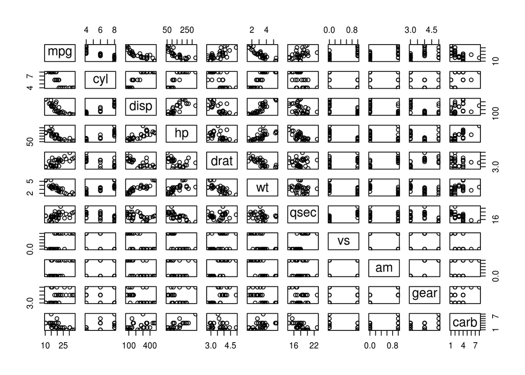

```r
pairs(mtcars)
```

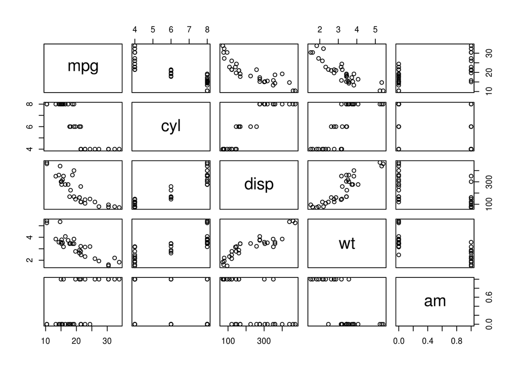

```r
#select some ones
pairs(mtcars[c("mpg","cyl","disp","wt","am")])
```

### Linear Model

```r
print("Number of cylinders")
```

```
## [1] "Number of cylinders"
```

```r
fit1<-lm(cyl~., mtcars)
fit1
```

```
##
## Call:
## lm(formula = cyl ~ ., data = mtcars)
##
## Coefficients:
## (Intercept)          mpg         disp           hp         drat           wt
##   12.107199    -0.004857     0.004610     0.003723    -0.427435    -0.222489
##        qsec           vs           am         gear         carb
##   -0.187945    -0.644076    -0.500770    -0.500323     0.179872
```

```r
print("Weight")
```

```
## [1] "Weight"
```

```r
fit2<-lm(wt~., mtcars)
fit2
```

```
##
## Call:
## lm(formula = wt ~ ., data = mtcars)
##
## Coefficients:
## (Intercept)          mpg          cyl         disp           hp         drat
##   -0.230634    -0.041666    -0.057254     0.006685    -0.003230    -0.090083
##        qsec           vs           am         gear         carb
##    0.199541    -0.066368     0.018445    -0.093508     0.248688
```

```r
print("miles / (US) gallon")
```

```
## [1] "miles / (US) gallon"
```

```r
fit3<-lm(mpg~., mtcars)
fit3
```

```
##
## Call:
## lm(formula = mpg ~ ., data = mtcars)
##
## Coefficients:
## (Intercept)          cyl         disp           hp         drat           wt
##    12.30337     -0.11144      0.01334     -0.02148      0.78711     -3.71530
##        qsec           vs           am         gear         carb
##     0.82104      0.31776      2.52023      0.65541     -0.19942
```

### Searching the most p-value

```r
value<-names(mtcars)
p<-NULL
#append(fit_list, lm(get(value[1])~get(value[2]), mtcars))
for (i in value) {
  if (value[1]!=i){
    p[i]<-summary(lm(get(value[1])~get(i), mtcars))$coef[2,4]
  }
}

# this is the minimum p-value for mpg with wich variable
min(p)
```

```
## [1] 1.293959e-10
```

Now we will search the variable wich is more correlated to the mpg *Miles/(US) gallon*

```r
p[p==min(p)]
```

```
##           wt
## 1.293959e-10
```

```r
summary(lm(mpg~wt, mtcars))$coef
```

```
##              Estimate Std. Error   t value     Pr(>|t|)
## (Intercept) 37.285126   1.877627 19.857575 8.241799e-19
## wt          -5.344472   0.559101 -9.559044 1.293959e-10
```

We conclude that there is relationsheep between **weigth** and mpg with slope equal to ** *-5.344* **